# Stats workshop

## Mark’s Data

This wont just be a *lesson* about what to do when one has new data. This will be an actual example of what I would do when I have new data. Mark has sent me some of his data and I haven’t done anything but download it yet. So, this is actually me playing around with new data. Let’s see what I’m gonna do (even I don’t know!). =)

#### A quick digression on organization

This doesn’t matter much at first, but once you have multiple projects, and are collaborating with multiple people, and these projects drag out over <sub>months</sub> years, organization can really become difficult to maintain. There are ways to keep organized, however! I recently found a nice, short, readable [guide](http://faculty.chicagobooth.edu/matthew.gentzkow/research/CodeAndData.pdf) on all the stuff I’ve spent a while figuring out on my own. Some of what you will find in there you will find more or less relevant (check out chapters 3 and 4 in particular), but I’ll emphasize a couple of things:

1. Use version control. [Github](https://github.com/) is easy to use, especially when you download their [gui](https://mac.github.com/). You’ll never have to worry about having multiple, conflicting, unclear analysis files again for fear of losing something you wrote previously.
2. Write your analysis code so that you can run the whole thing from start to finish. It helps even more if you write it in [markdown](http://rmarkdown.rstudio.com/) (or something similar) with prose explaining what you’re doing and what you’re thinking. From there, it’s only a short step to turn it into a methods/results section.

Of course, I should put caveats all around this thing because I often don’t really know what I’m doing either. I’ve never had a data set where I was doing all the same old things. It’s a constant process of learning something new. And while I’ve been fighting the organization war for years, it’s only in the last 6 months or so that I’ve really decided that this was something I had to win. =)

### Get the data in and look at what we’ve got

First, let’s get it in. I’m sure you’re all familiar with how to do this. However, it helps to keep things organized. Everything related to this project should all be in the same folder. I’ve put Mark’s data in the same folder I’m keeping this script. Before doing anything, you should click Session -> Set Working Directory -> To Source File Location.

I wish there were an automatic way to do that. Unfortunately, I don’t think there is. Anyway, once that’s done, we can move on to read in his data and get the dimensions.

```r
breach <- read.csv('Data/breachmeans.csv')
dim(breach)
```

```
## [1] 20 32
```

Okay! We’ve got 20 observations for each of 32 variables. Let’s look a little more closely at what those variables are. Next, I’m going to get the names of each variable:

```r
names(breach)
```

```
##  [1] "subj"           "locomotion1"    "locomotion2"    "difflocomotion"
##  [5] "assessment1"    "assessment2"    "diffassessment" "promotion1"
##  [9] "promotion2"     "diffpromotion"  "prevention1"    "prevention2"
## [13] "diffprevention" "stress1"        "stress2"        "diffstress"
## [17] "flourishing"    "swls"           "lie2"           "lie1"
## [21] "diffLie"        "LxA1"           "LxA2"           "diffLxA"
## [25] "age"            "exp"            "apride"         "lpride"
## [29] "eom"            "rankindiv"      "rank21"         "averank"
```

Now, a bit of a closer look at what these things contain:

```r
head(breach)
```

```
##   subj locomotion1 locomotion2 difflocomotion assessment1 assessment2
## 1    1        5.00        4.58        -0.4167        4.17        3.67
## 2    2        4.50        4.58         0.0833        4.25        3.92
## 3    3        5.25        4.83        -0.4167        4.00        4.00
## 4    4        4.83        5.00         0.1667        4.00        3.83
## 5    5        5.08        4.92        -0.1667        4.50        3.83
## 6    6        5.08        4.75        -0.3333        5.00        4.08
##   diffassessment promotion1 promotion2 diffpromotion prevention1
## 1        -0.5000       3.50       4.00         0.500         1.8
## 2        -0.3333       4.00       4.17         0.167         2.2
## 3         0.0000       4.17       3.83        -0.333         1.0
## 4        -0.1667       4.00       4.50         0.500         2.2
## 5        -0.6667       4.83       4.83         0.000         3.4
## 6        -0.9167       4.00       4.33         0.333         2.4
##   prevention2 diffprevention stress1 stress2 diffstress flourishing swls
```

[output cut: 20 more lines]

```r
summary(breach)
```

```
##       subj        locomotion1     locomotion2    difflocomotion
##  Min.   : 1.00   Min.   :3.830   Min.   :3.580   Min.   :-1.7500
##  1st Qu.: 5.75   1st Qu.:4.647   1st Qu.:4.560   1st Qu.:-0.3542
##  Median :10.50   Median :5.000   Median :4.920   Median :-0.2084
##  Mean   :10.50   Mean   :4.949   Mean   :4.816   Mean   :-0.1333
##  3rd Qu.:15.25   3rd Qu.:5.122   3rd Qu.:5.270   3rd Qu.: 0.2708
##  Max.   :20.00   Max.   :5.750   Max.   :5.420   Max.   : 0.5000
##
##   assessment1     assessment2    diffassessment      promotion1
##  Min.   :3.750   Min.   :3.500   Min.   :-1.3333   Min.   :3.500
##  1st Qu.:4.000   1st Qu.:3.830   1st Qu.:-0.5417   1st Qu.:3.830
##  Median :4.290   Median :3.920   Median :-0.3333   Median :4.000
##  Mean   :4.351   Mean   :4.017   Mean   :-0.3333   Mean   :4.058
##  3rd Qu.:4.543   3rd Qu.:4.122   3rd Qu.:-0.1459   3rd Qu.:4.210
##  Max.   :5.170   Max.   :4.920   Max.   : 1.1667   Max.   :4.830
##
##    promotion2    diffpromotion       prevention1    prevention2
##  Min.   :3.170   Min.   :-0.83300   Min.   :1.00   Min.   :1.4
##  1st Qu.:3.830   1st Qu.:-0.33300   1st Qu.:2.20   1st Qu.:2.2
##  Median :4.000   Median : 0.08350   Median :2.60   Median :2.7
##  Mean   :4.041   Mean   :-0.01665   Mean   :2.53   Mean   :2.6
##  3rd Qu.:4.330   3rd Qu.: 0.33300   3rd Qu.:3.00   3rd Qu.:3.0
##  Max.   :4.830   Max.   : 0.50000   Max.   :3.80   Max.   :3.4
##
##  diffprevention     stress1         stress2        diffstress
##  Min.   :-0.80   Min.   :1.380   Min.   :1.000   Min.   :-0.75000
##  1st Qu.:-0.25   1st Qu.:1.685   1st Qu.:1.718   1st Qu.:-0.12500
##  Median : 0.20   Median :1.880   Median :2.000   Median : 0.00000
##  Mean   : 0.07   Mean   :2.013   Mean   :2.068   Mean   : 0.08553
##  3rd Qu.: 0.40   3rd Qu.:2.250   3rd Qu.:2.530   3rd Qu.: 0.37500
##  Max.   : 0.80   Max.   :3.500   Max.   :3.120   Max.   : 0.62500
##                  NA's   :1                       NA's   :1
##   flourishing         swls           lie2            lie1
##  Min.   :4.880   Min.   :4.40   Min.   :1.000   Min.   :1.000
##  1st Qu.:5.750   1st Qu.:5.75   1st Qu.:2.290   1st Qu.:2.290
##  Median :6.000   Median :5.80   Median :2.670   Median :2.500
##  Mean   :5.976   Mean   :5.91   Mean   :2.675   Mean   :2.632
##  3rd Qu.:6.250   3rd Qu.:6.20   3rd Qu.:3.042   3rd Qu.:3.000
##  Max.   :7.000   Max.   :7.00   Max.   :4.670   Max.   :4.500
##
```

[output cut: 9 more lines]

```
##  Min.   :21.0   Min.   :0.00   Min.   :28.00   Min.   :29.00
##  1st Qu.:24.0   1st Qu.:2.00   1st Qu.:36.00   1st Qu.:38.00
##  Median :26.0   Median :3.00   Median :38.00   Median :41.50
##  Mean   :25.9   Mean   :3.25   Mean   :37.45   Mean   :41.35
##  3rd Qu.:28.0   3rd Qu.:4.00   3rd Qu.:39.00   3rd Qu.:46.00
##  Max.   :31.0   Max.   :8.00   Max.   :46.00   Max.   :49.00
##
##       eom          rankindiv         rank21         averank
##  Min.   :34.00   Min.   : 1.00   Min.   : 1.00   Min.   : 1.500
##  1st Qu.:37.00   1st Qu.: 5.75   1st Qu.: 5.75   1st Qu.: 5.875
##  Median :38.50   Median :10.50   Median :11.00   Median :10.500
##  Mean   :38.45   Mean   :10.50   Mean   :11.00   Mean   :10.750
##  3rd Qu.:40.00   3rd Qu.:15.25   3rd Qu.:16.25   3rd Qu.:16.500
##  Max.   :43.00   Max.   :20.00   Max.   :21.00   Max.   :20.000
##
```

```r
str(breach)
```

```
## 'data.frame':    20 obs. of  32 variables:
##  $ subj          : int  1 2 3 4 5 6 7 8 9 10 ...
##  $ locomotion1   : num  5 4.5 5.25 4.83 5.08 5.08 4.67 5 5.58 5.08 ...
##  $ locomotion2   : num  4.58 4.58 4.83 5 4.92 4.75 5.08 4.33 5.25 5.33 ...
##  $ difflocomotion: num  -0.4167 0.0833 -0.4167 0.1667 -0.1667 ...
##  $ assessment1   : num  4.17 4.25 4 4 4.5 5 4 4.5 4.42 4.25 ...
##  $ assessment2   : num  3.67 3.92 4 3.83 3.83 4.08 3.5 4 3.67 3.92 ...
##  $ diffassessment: num  -0.5 -0.333 0 -0.167 -0.667 ...
##  $ promotion1    : num  3.5 4 4.17 4 4.83 4 3.83 3.83 4 4.67 ...
##  $ promotion2    : num  4 4.17 3.83 4.5 4.83 4.33 4.17 3.5 3.83 4 ...
##  $ diffpromotion : num  0.5 0.167 -0.333 0.5 0 0.333 0.333 -0.333 -0.167 -0.667 ...
##  $ prevention1   : num  1.8 2.2 1 2.2 3.4 2.4 2.8 3 2.8 2.6 ...
##  $ prevention2   : num  2.2 2.2 1.4 2 3 2.2 3 2.8 3.2 2.8 ...
##  $ diffprevention: num  0.4 0 0.4 -0.2 -0.4 -0.2 0.2 -0.2 0.4 0.2 ...
##  $ stress1       : num  1.62 2 2.38 2 2 1.75 3.5 2.25 1.75 1.75 ...
```

[output cut: 18 more lines]

This highlights that within R, the dataframe is really just a collection of vectors. Mark has two types: `numeric` and `integer`.

##### Question:

**1. We wont always be fortunate enough to have .csv files. How can we read in excel files? Spss? STATA? Word?**

```
library(xlsx)
read.xlsx()
library(foreign)
read.spss()
read.dta()
```

Microsoft word is possible (everything is *possible*), but a bit more complicated (see `tm` package)

### Data types

From an R standpoint, there are few differences between `numeric` and `integer` types. It’s good to know they exist, because the type of object you pass to functions can be a major source of headaches (e.g. if a function expects a `factor` and you try to pass it a `numeric`), but for now, we can generally treat `numeric` and `integers` as the same thing - quantitative variables. This can be contrasted with two other types that we do not see here: `factors` and `characters`. A factor is a categorical variable, and a character is just a collection of text strings. Let’s go ahead and make a couple of these. First, we’ll make a variable indicating whether someone is happy or not:

```r
breach$happy <- rep(c("yes", "no"), each=10)
breach$happy #there's only 20 observations, so we can just print out all of them.
```

```
##  [1] "yes" "yes" "yes" "yes" "yes" "yes" "yes" "yes" "yes" "yes" "no"
## [12] "no"  "no"  "no"  "no"  "no"  "no"  "no"  "no"  "no"
```

```r
str(breach$happy)
```

```
##  chr [1:20] "yes" "yes" "yes" "yes" "yes" "yes" "yes" ...
```

```r
summary(breach$happy)
```

```
##    Length     Class      Mode
##        20 character character
```

Ah! A `character` variable! But that’s just because we fed it some text strings, isn’t it? As psychologists, we know that this is actually a categorical variable. People fall into one of two categories: Those who are happy, and those who have failed research projects. ;)

Anyway, since this is a categorical variable, we want this to be a `factor`.

```r
breach$happy <- as.factor(breach$happy)
breach$happy
```

```
##  [1] yes yes yes yes yes yes yes yes yes yes no  no  no  no  no  no  no
## [18] no  no  no
## Levels: no yes
```

```r
str(breach$happy)
```

```
##  Factor w/ 2 levels "no","yes": 2 2 2 2 2 2 2 2 2 2 ...
```

```r
summary(breach$happy)
```

```
##  no yes
##  10  10
```

You can see that calling some of the same functions on data which is identical in appearance but *stored* in two different ways can lead to some very different output. It’s key to keep this in mind no matter what you’re doing in R. If something doesn’t work the way you expect it to, maybe it’s because you’re feeding in an unexpected data type. I think I spent about a month in my third year figuring this out. A long, painful month.

##### Questions:

1. Let’s say Mark ran a study in which his participants recieved 2, 4, or 8 ‘happy’ primes. We create a factor variable which distinguishes these groups:

   `a <- as.factor(rep(c(2,4,8), each=10))`

   For some purposes, this will be fine. But let’s say for some reason we want to treat this as a numeric value rather than a factor. We run the following command:

   `a <- as.numeric(a)`

   What happened? Did it work as you expected?
2. How are factor variables represented internally in R (*hint*: Why, when we call `str(breach$happy)`, do we get a bunch of numbers)? What’s the logic behind their representation?

Now that we know a little bit about data types, let’s think of what types of things we might be interested in looking at. It’s time to know a bit about `ggplot`, don’t you think?

### Preliminary visualizations

ggplot is a package built by the incredibly productive [Hadley Wickham](http://had.co.nz). It follows a general plotting philosophy published and described elsewhere called *Grammer of Graphics*. To create a ggplot object, you must first decide what you’re plotting. Since I see that we have two scores for most of our measurements (plus I’ve spoken to Mark about this work a few times), I’m going to treat these as two measurements of the same concept on the same individual. One thing we obviously might be interested in is how these measurements changed between session one and session two.

Please note that there’s no hypothesis testing going on yet! We’re just looking at data! You should spend quite a lot of time doing this. Anyway, on with it. Let’s make a couple of histograms for the locomotion variable.

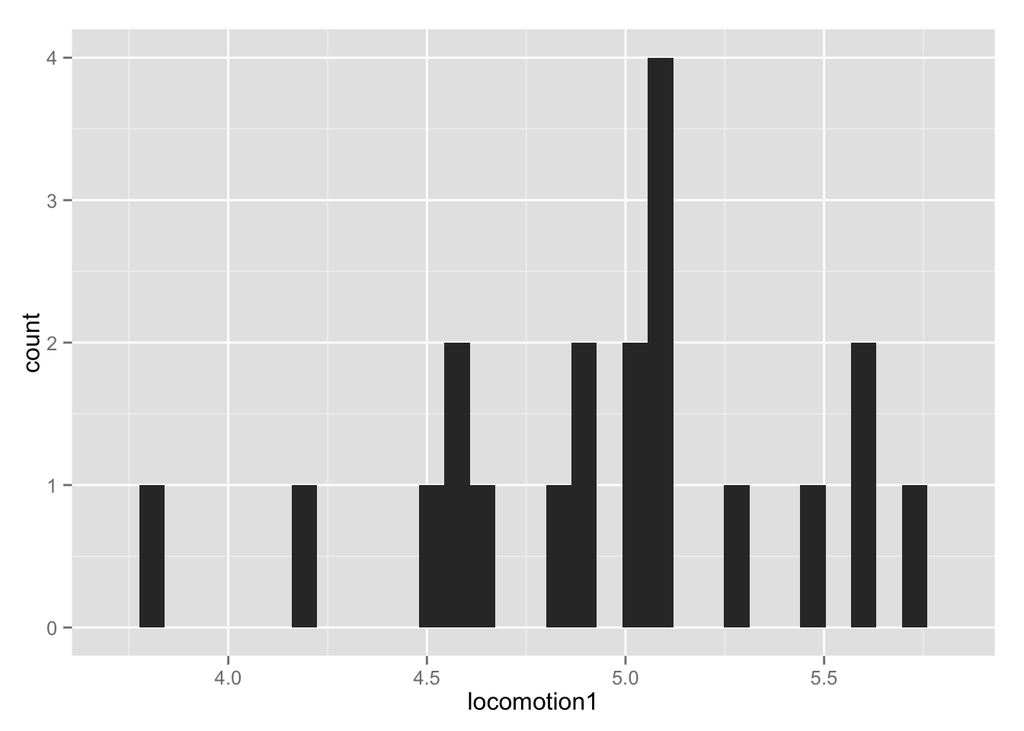

```r
library(ggplot2)
plot <- ggplot(breach, aes(x=locomotion1))
plot + geom_histogram()
```

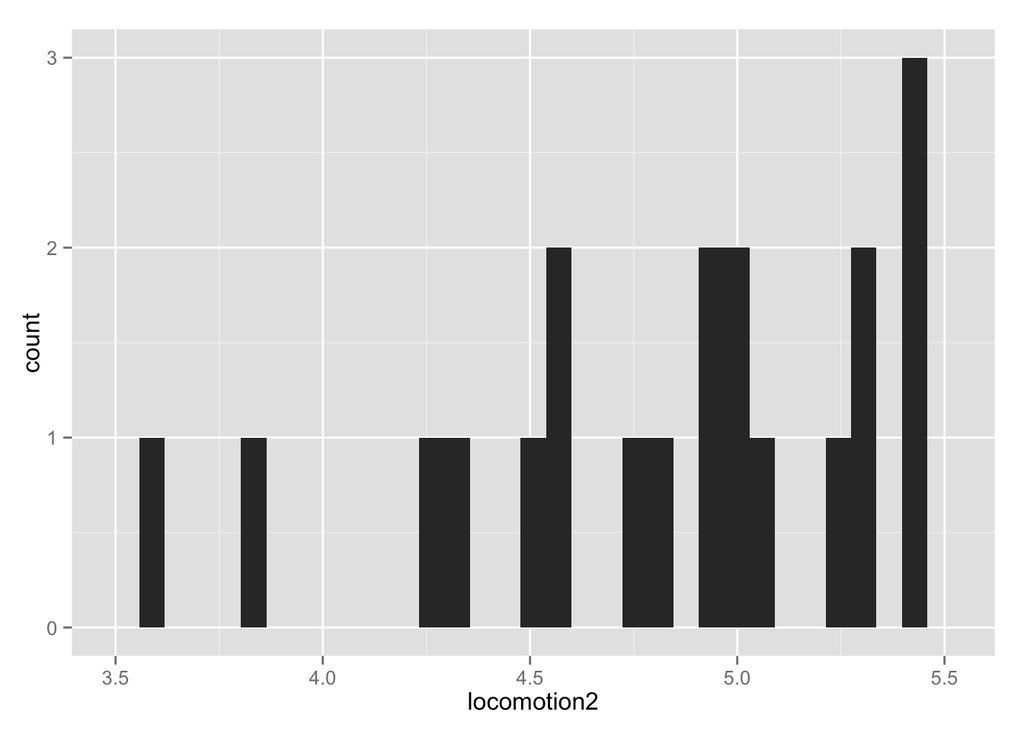

```r
plot <- ggplot(breach, aes(x=locomotion2))
plot + geom_histogram()
```

Before we pull apart the figures, let’s look at what we’ve done here. For each plot, there are two lines of code. The first line from the first plot:

`plot <- ggplot(breach, aes(x=locomotion1))`

This makes an object we’ve called `plot`. This object is stored internally as a list, but we don’t really care about that. What we care about is that this is a ggplot object made from the `breach` dataframe (1st argument). We’ve also assigned some aesthetics (via `aes`) for this particular plot. In particular, we’ve told it that we want the variable `locomotion1` to appear on the x axis (2nd argument). This will create an empty plot, onto which we can begin placing layers. Each layer added to the plot will do something to change the superficial appearance. However, in general, after the first line, we’ve already given R **all** the data we need to make the figure we’re going for. Now, all we need to do is specify exactly what we want the data to look like. The next line:

`plot + geom_histogram()`

Here, we’ve taken the empty plot object, and added a layer. This layer takes the form of a histogram, but it could have just as easily been something else. There aren’t very many layers which will work without some additional information (like a second variable), but just for kicks, here’s an example of something else we *could* have done:

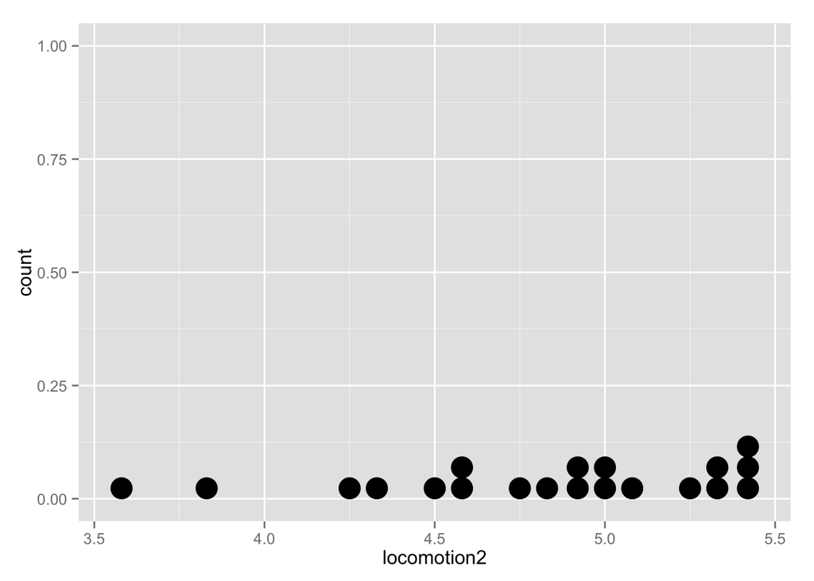

```r
plot + geom_dotplot()
```

We’ve taken the exact same underlying object (`plot`), and added a different layer. It’s clear that the underlying data is the same, but this lets us visualize it in a slightly different way.

The original objective, however, was to compare the first locomotion score to the second. While we can do that with these plots, it isn’t ideal for this purpose for a couple of reasons:

1. Having two separate plots forces us to shift our eyes back and forth between the two. It would be much better if they were plotted together.
2. The sparsity of our data leads our histogram to be not-very-smooth. Kind of chunky looking. I love chunky peanut butter, but histograms, not so much.

So, we can fix this by plotting both of these variables on the same object, letting them overlap somehow, and using a different kind of layer. But wait! How can we do this? Look back at the creation of the plotting object:

`plot <- ggplot(breach, aes(x=locomotion1))`

We’ve assigned a variable to x, but what we want is to have TWO variables on x. Your intuition may say to do this:

`plot <- ggplot(breach, aes(x=c(locomotion1, locomotion2)))`

Your intuition would be wrong. This will plot just fine, but it isn’t what we want. Here, R has no way of knowing which scores are from `locomotion1` and `locomotion2`, and so will just plot them all together. Observe:

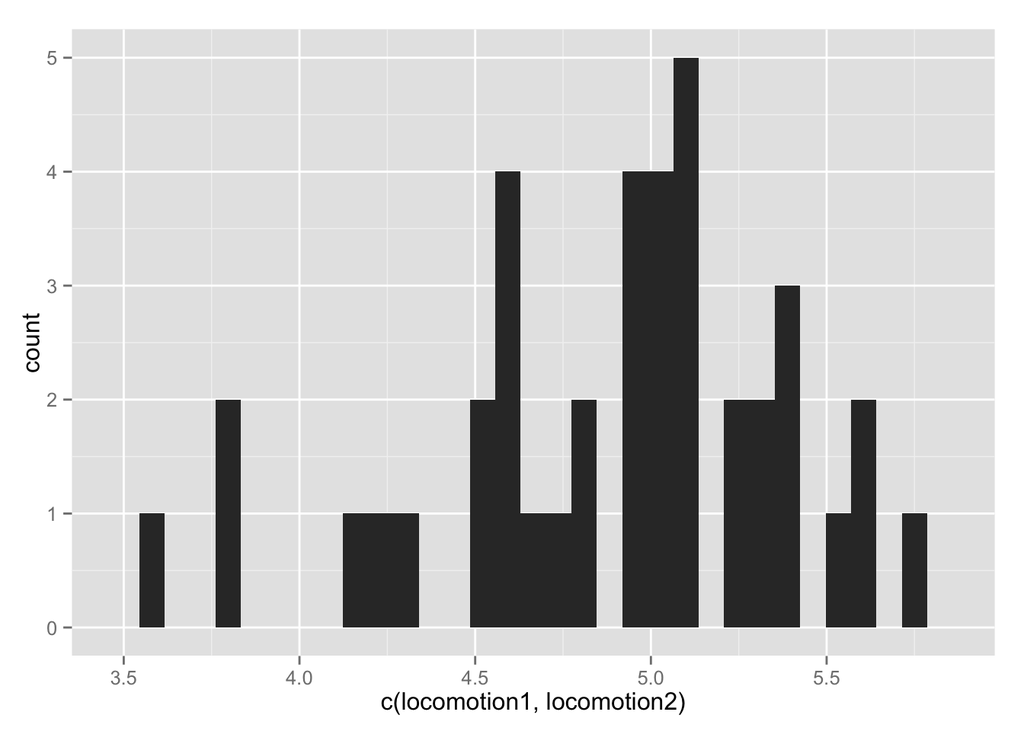

```r
plot <- ggplot(breach, aes(x=c(locomotion1, locomotion2)))
plot + geom_histogram()
```

*Side note: using `c()` will combine things into a vector. As soon as you perform `c()` on something, all the component parts are treated as coming from the same thing.*

We can get around this issue, but it requires some wrangling of our data. To preview, we will eventually aim to have two vectors in our dataframe: one of the values to be plotted along the x axis, and another indicating which of two groups each value belongs to.

##### Questions:

1. There are other reasons we might not like the plots we just produced. For example, maybe we want the bins into which the observations are sorted to be a bit larger. Can you do this? What setting do you think produces the best visualization for the data? (*hint*: `?geom_histogram`)
2. In the last plot, the x axis label is horrible. Change it to something more appropriate. You might find [this](http://docs.ggplot2.org/current/) helpful.

### Reshaping

We’re going to reshape our data so that we can feed it into ggplot. Mark’s data is currently organized in the ‘wide’ format. In psychology studies, this usually means that each row is an individual, and everything we know or have collected from that individual is on that row. For many statistical computing purposes, it is common to use a ‘long’ format. Here, the rows take the form of observations on an individual. Since we’re observing many of our variables twice on the same individual, this implies that each individual will have two rows. If we had done an experiment with, let’s say, 200 reaction time trials, then we would have 200 rows for each individual in a ‘long’ format.

In order to get this data from wide to long, we can use the `reshape2` package, created by….yep, that’s right. Our dear friend [Hadley Wickham](http://had.co.nz). (I know! This guy! Jeez! Everytime I load one of his packages I think about sending him one of the books on his [amazon wishlist](http://www.amazon.com/gp/registry/1Y65N3VFA613B)).

There are two main functions in the `reshape2` package: `melt` and `cast`. The former takes wide data and converts it to long, and the latter does the converse. We need to our wide data to be long, so we need to use melt.

```r
library(reshape2)
breach <- melt(breach,
     id.vars = c('subj', 'flourishing', 'swls', 'age', 'exp', 'apride',
                 'lpride', 'eom', 'rankindiv', 'rank21', 'averank'),
     measure.vars = c('locomotion1', 'locomotion2', 'assessment1', 'assessment2',
                      'promotion1', 'promotion2', 'prevention1', 'prevention2',
                      'stress1', 'stress2', 'lie2', 'lie1', 'LxA1', 'LxA2'))
str(breach)
```

```
## 'data.frame':    280 obs. of  13 variables:
##  $ subj       : int  1 2 3 4 5 6 7 8 9 10 ...
##  $ flourishing: num  6.5 5.25 6.25 6.88 6.25 6 7 6 5.75 6 ...
##  $ swls       : num  6 5.8 6.2 6.8 6.2 5.6 7 5.8 5.8 5.8 ...
##  $ age        : int  23 26 22 26 26 29 28 24 27 22 ...
##  $ exp        : int  3 6 4 2 4 3 0 3 4 1 ...
##  $ apride     : int  37 38 32 40 45 38 38 33 36 37 ...
##  $ lpride     : int  46 38 40 46 44 44 49 40 38 38 ...
##  $ eom        : int  40 35 43 42 38 34 39 41 38 37 ...
##  $ rankindiv  : int  10 4 6 16 3 5 12 9 11 19 ...
##  $ rank21     : num  13 3.5 5 16 3.5 7 21 10 8 15 ...
##  $ averank    : num  11.5 3.75 5.5 16 3.25 6 16.5 9.5 9.5 17 ...
##  $ variable   : Factor w/ 14 levels "locomotion1",..: 1 1 1 1 1 1 1 1 1 1 ...
##  $ value      : num  5 4.5 5.25 4.83 5.08 5.08 4.67 5 5.58 5.08 ...
```

```r
summary(breach)
```

```
##       subj        flourishing         swls           age
##  Min.   : 1.00   Min.   :4.880   Min.   :4.40   Min.   :21.0
##  1st Qu.: 5.75   1st Qu.:5.750   1st Qu.:5.75   1st Qu.:24.0
##  Median :10.50   Median :6.000   Median :5.80   Median :26.0
##  Mean   :10.50   Mean   :5.976   Mean   :5.91   Mean   :25.9
##  3rd Qu.:15.25   3rd Qu.:6.250   3rd Qu.:6.20   3rd Qu.:28.0
##  Max.   :20.00   Max.   :7.000   Max.   :7.00   Max.   :31.0
##
##       exp           apride          lpride           eom
##  Min.   :0.00   Min.   :28.00   Min.   :29.00   Min.   :34.00
##  1st Qu.:2.00   1st Qu.:36.00   1st Qu.:38.00   1st Qu.:37.00
##  Median :3.00   Median :38.00   Median :41.50   Median :38.50
##  Mean   :3.25   Mean   :37.45   Mean   :41.35   Mean   :38.45
##  3rd Qu.:4.00   3rd Qu.:39.00   3rd Qu.:46.00   3rd Qu.:40.00
##  Max.   :8.00   Max.   :46.00   Max.   :49.00   Max.   :43.00
##
##    rankindiv         rank21         averank              variable
##  Min.   : 1.00   Min.   : 1.00   Min.   : 1.500   locomotion1: 20
##  1st Qu.: 5.75   1st Qu.: 5.75   1st Qu.: 5.875   locomotion2: 20
##  Median :10.50   Median :11.00   Median :10.500   assessment1: 20
##  Mean   :10.50   Mean   :11.00   Mean   :10.750   assessment2: 20
##  3rd Qu.:15.25   3rd Qu.:16.25   3rd Qu.:16.500   promotion1 : 20
##  Max.   :20.00   Max.   :21.00   Max.   :20.000   promotion2 : 20
##                                                   (Other)    :160
##      value
##  Min.   : 1.000
##  1st Qu.: 2.600
##  Median : 3.830
##  Mean   : 6.367
##  3rd Qu.: 4.830
##  Max.   :33.100
##  NA's   :1
```

Okay, we’re getting closer. We can see that we’ve now got 280 observations across 13 different variables. How did this happen and what are we left with? Let’s look at the melt function, line-by-line.

`breach <- melt(breach,`

Nothing mind-blowing here. We’ve just called the `melt` function, and then fed it our dataframe as the first argument. The next line is the `id.vars` argument:

`id.vars = c('subj', 'flourishing', 'swls', 'age', 'exp', 'apride', 'lpride', 'eom', 'rankindiv', 'rank21', 'averank'),`

If we look closely at the updated breach dataframe, it’s clear that these are the variables which get repeated. That is, while there are only 20 subjects, each subject now has their data spread across 14 rows. All the other variables listed in this argument are similarly repeated. Finally, we have the `measure.vars` argument:

`measure.vars = c('locomotion1', 'locomotion2', 'assessment1', 'assessment2', 'promotion1', 'promotion2', 'prevention1', 'prevention2', 'stress1', 'stress2', 'lie2', 'lie1', 'LxA1', 'LxA2'))`

What happened to all of these in our new dataframe? it seems they’ve all been dumped into two new variables. One has the name `variables` and the other has the name `value`. Let’s examine the data for subject 2.

```r
breach[breach$subj == 2,] #read:  from the dataframe breach, give me the rows where subject = 2.  After the comma is where one would select columns.  Since I wanted all the columns, I just left it blank.
```

```
##     subj flourishing swls age exp apride lpride eom rankindiv rank21
## 2      2        5.25  5.8  26   6     38     38  35         4    3.5
## 22     2        5.25  5.8  26   6     38     38  35         4    3.5
## 42     2        5.25  5.8  26   6     38     38  35         4    3.5
## 62     2        5.25  5.8  26   6     38     38  35         4    3.5
## 82     2        5.25  5.8  26   6     38     38  35         4    3.5
## 102    2        5.25  5.8  26   6     38     38  35         4    3.5
## 122    2        5.25  5.8  26   6     38     38  35         4    3.5
## 142    2        5.25  5.8  26   6     38     38  35         4    3.5
## 162    2        5.25  5.8  26   6     38     38  35         4    3.5
## 182    2        5.25  5.8  26   6     38     38  35         4    3.5
## 202    2        5.25  5.8  26   6     38     38  35         4    3.5
## 222    2        5.25  5.8  26   6     38     38  35         4    3.5
## 242    2        5.25  5.8  26   6     38     38  35         4    3.5
## 262    2        5.25  5.8  26   6     38     38  35         4    3.5
##     averank    variable value
## 2      3.75 locomotion1  4.50
## 22     3.75 locomotion2  4.58
## 42     3.75 assessment1  4.25
## 62     3.75 assessment2  3.92
## 82     3.75  promotion1  4.00
## 102    3.75  promotion2  4.17
## 122    3.75 prevention1  2.20
## 142    3.75 prevention2  2.20
## 162    3.75     stress1  2.00
## 182    3.75     stress2  2.50
## 202    3.75        lie2  2.67
## 222    3.75        lie1  2.33
## 242    3.75        LxA1 20.20
## 262    3.75        LxA2 21.00
```

This (I think) really clearly illustrates what’s going on here. Two things happen with all the variables listed in the `measure.vars` argument. First, the name of each variable gets put into a new vector called, unfortunately `variable`. Second, the corresponding value for that variable is listed in a second new vector labeled ‘value’. Thus, since we had 14 variables listed in `measure.vars`, we now have 14 lines for each subject.

But, like I pointed out before, this isn’t quite what we wanted. Remember our goal: We want a histogram where we can plot two variables on the x axis. And remember how I said we would do it:

**2 vectors**  
- *Vector 1: values to be plotted*  
- *Vector 2: indicates which of two groups each value belongs to.*

I know we just turned our ‘wide’ data into ‘long’, but now we need to go back. Our data is long, but it’s *too* long… (yeah, yeah… har har). I can think of two ways to do this. One that is simpler, but pretty inflexible, and another which is a little more show-offy, a bit trickier, but also a little more flexible (by flexibility, I mean the idea could work for more instances than just this one). We will start with the straightforward one!

First, let’s notice that the repeated measurements of the same variable are all stacked on top of each other. For example, all measurements of `locomotion1` occur in the first 20 rows of our data frame

```r
breach[1:25, ] #read:  give me the rows 1 through 25, all columns.
```

```
##    subj flourishing swls age exp apride lpride eom rankindiv rank21
## 1     1        6.50  6.0  23   3     37     46  40        10   13.0
## 2     2        5.25  5.8  26   6     38     38  35         4    3.5
## 3     3        6.25  6.2  22   4     32     40  43         6    5.0
## 4     4        6.88  6.8  26   2     40     46  42        16   16.0
## 5     5        6.25  6.2  26   4     45     44  38         3    3.5
## 6     6        6.00  5.6  29   3     38     44  34         5    7.0
## 7     7        7.00  7.0  28   0     38     49  39        12   21.0
## 8     8        6.00  5.8  24   3     33     40  41         9   10.0
## 9     9        5.75  5.8  27   4     36     38  38        11    8.0
## 10   10        6.00  5.8  22   1     37     38  37        19   15.0
## 11   11        6.12  6.0  24   2     36     48  40         8    6.0
## 12   12        5.88  5.6  28   2     38     46  37        15   18.0
## 13   13        5.75  5.8  30   6     41     36  40         7    9.0
## 14   14        5.88  5.6  29   3     39     43  40        20   20.0
```

[output cut: 37 more lines]

After that, we see that the next 20 rows (i.e. 21-40) are all `locomotion2`

```r
breach[breach$variable=='locomotion2', c(1:5, 12)] #read:  give me all the rows where the value for variable is equal to locomotion 2.  only give me columns 1 through 5 and 12 (column 12 is the `variable` column)
```

```
##    subj flourishing swls age exp    variable
## 21    1        6.50  6.0  23   3 locomotion2
## 22    2        5.25  5.8  26   6 locomotion2
## 23    3        6.25  6.2  22   4 locomotion2
## 24    4        6.88  6.8  26   2 locomotion2
## 25    5        6.25  6.2  26   4 locomotion2
## 26    6        6.00  5.6  29   3 locomotion2
## 27    7        7.00  7.0  28   0 locomotion2
## 28    8        6.00  5.8  24   3 locomotion2
## 29    9        5.75  5.8  27   4 locomotion2
## 30   10        6.00  5.8  22   1 locomotion2
## 31   11        6.12  6.0  24   2 locomotion2
## 32   12        5.88  5.6  28   2 locomotion2
## 33   13        5.75  5.8  30   6 locomotion2
## 34   14        5.88  5.6  29   3 locomotion2
## 35   15        4.88  5.8  24   2 locomotion2
## 36   16        6.25  6.0  31   5 locomotion2
## 37   17        5.50  6.4  25   3 locomotion2
## 38   18        6.00  5.4  27   8 locomotion2
## 39   19        5.00  4.4  21   2 locomotion2
## 40   20        6.38  6.2  26   2 locomotion2
```

Noticing a pattern? Just to be sure, let’s look at the next 20 rows:

```r
breach[41:60, c('subj', 'variable')]
```

```
##    subj    variable
## 41    1 assessment1
## 42    2 assessment1
## 43    3 assessment1
## 44    4 assessment1
## 45    5 assessment1
## 46    6 assessment1
## 47    7 assessment1
## 48    8 assessment1
## 49    9 assessment1
## 50   10 assessment1
## 51   11 assessment1
## 52   12 assessment1
## 53   13 assessment1
## 54   14 assessment1
## 55   15 assessment1
## 56   16 assessment1
## 57   17 assessment1
## 58   18 assessment1
## 59   19 assessment1
## 60   20 assessment1
```

Okay! That seems to confirm! Our two groups are repeated in chunks of 20 all the way down the data frame. That means we can just manually make a new variable which indicates which measurement occasion these came from.

```r
breach$time <- rep(rep(c(1, 2), each = 20), 7)
```

Understand that? Lets look at that line one piece at a time. First, we’re making a new variable called time. Looking at the innermost bit of the function:

`rep(c(1,2), each=20)`

We’ve created a small vector `[1, 2]`, and applied the `rep` (i.e. repeat) function to it. The second argument `each=20` means that I’d like for each instance in that small vector to be repeated 20 times. Thus, this creates a longer vector of 20 instances of `1` and 20 instances of `2`. We’ll call everything inside that innermost function `a`. The outer function from above, with the stuff in the middle replaced by `a` is:

`rep(a, 7)`

This takes `a` and just repeats it 7 times. Remember `a`is 20 instances of `1` and 20 instances of `2`. So it’s length is 40. Repeating it seven times gives $40*7 = 280$, which is exactly as long as our dataframe.

This leaves us with a new variable indicating which of two measurement observations each row comes from. Now, we can create a plot of the how any given variable differs by time. I’m also going to use a short regular expression here to select all instances of `variable` which contain the text `locomotion`.

```r
#plot <- ggplot(breach[grep("locomotion", variable), ], aes(x=value, color=time))
#plot + geom_density()

#This throws an error:
#Error in unit(tic_pos.c, "mm") : 'x' and 'units' must have length > 0
```

Okay, this results in an error, and it took me about 10 minutes to figure out why. However, let’s take it apart to see what is *supposed* to happen. First:

`ggplot(breach[grep("locomotion", breach$variable), ], ...`

Where we usually feed in the dataframe, this time, we’ve fed in just a subset of the dataframe. I’ve used a global regular expression (`grep`) to find all the instances in `variable` which have a match of the letter string `locomotion`. This gives me the 40 rows I’m interested in. Next:

`...aes(x=value, color=time))`

This isn’t too different from what we did before when we defined the aesthetic. We said we want `value` on the x axis, and that we’d like to give the data a different color depending on what is in the `time` vector. Finally:

`plot + geom_density()`

I’ve added a slightly different layer for visual aesthetic reasons. Since the histogram is a little chunky, and we’re overlaying two distrubtions on top of each other, it seemed like a good idea to use a density plot rather than a histogram. The information isn’t any different here, it just looks a bit better.

So, why the error? This is a nice case study in the importance of knowing what data types you’re working with. When we pass an argument to color, it is expecting collection of categories. In our case, we have two categories: time 1 and time 2. However, `time` is stored as a continuous variable:

```r
str(breach$time)
```

```
##  num [1:280] 1 1 1 1 1 1 1 1 1 1 ...
```

Even though we have only two values for time, since we fed it numbers and didn’t specify otherwise, R recognized it as a continuous numeric variable. Thus, it is stored internally as a `numeric`. The color argument in our ggplot wants discrete categories on which it can map discrete colors. So, if we just change what we feed into the `color` argument to a `factor`, this should work!

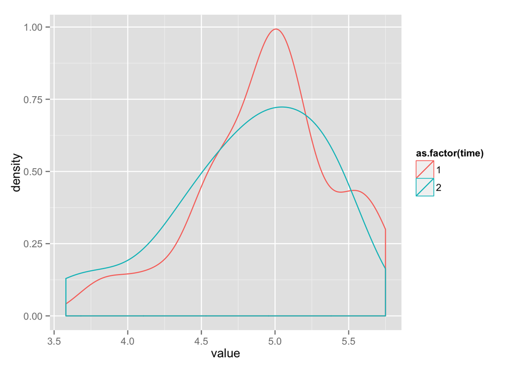

```r
plot <- ggplot(breach[grep("locomotion", breach$variable), ], aes(x=value, color=as.factor(time)))
plot + geom_density()
```